# Laboratory for Introduction to Data Science

Mark Mitri

9/11/2022

### This version by Prof. Davison

### Last edit: 14 July 2022

You will be

- Getting started with the data.world R package
- Using SQL to get datasets
- Learning how to merge tables
- Examining sample datasets, simple operations and plotting

## Interesting Sources of Data

Even without being part of an organization that is actively collecting data, there are many sources of interesting data:

- Jeremy Singer-Vine’s [Data Is Plural](https://data-is-plural.com/) newsletter of useful/curious datasets. Follow the link to a Google Sheet of archived datasets from his newsletter.
- The U.S. Government’s open data at [data.gov](https://data.gov/).
- Try [Google’s Dataset Search Service](https://datasetsearch.research.google.com/)
- The data-sharing social network and analysis environment for data scientists at [data.world](https://data.world/). We are spending time here today.

Note that inline image links like the following only show images when rendered (not in the editor). So **click on Preview->Preview Notebook** to generate a pretty version of these instructions.

[figure not shown]

data.world logo

This guide contains some material from the guide found at https://data.world/nrippner/explore-the-data-world-r-sdk. Look at that one for more complex queries and additional data.world functionality.

#### *Here we will introduce the data.world R package. While there’s a lot more that the R package can do, the techniques below comprise the key functions you’ll need to start doing work with data.world and R.*

#### **Agenda**:

1. Quickstart
2. Simple queries
3. Merging dataframes / SQL tables
4. Exercises

# 1. Quickstart

### Installation

Since the packages we want are not in the CRAN archive any longer, we have more work than normal to install.

Uncomment these to install the following once; then you can recomment out these lines. Each one will install the named packages plus any dependencies needed.

```r
 install.packages(c("httr","readr","rjson","xml2")) # these are prerequisites for dwapi package
 install.packages(c("ini","miniUI","shiny")) # these are additional prerequisites for data.world package
 install.packages("stringi") # sometimes needed, doesn't hurt to add
```

```
Error in install.packages : Updating loaded packages
```

Assuming you have completed the prior steps successfully (no Error in red print), uncomment to install the following once; then you can re-comment out these lines.

```r
# install.packages("https://cran.r-project.org/src/contrib/Archive/dwapi/dwapi_0.1.3.1.tar.gz", repos=NULL, type="source")
# install.packages("https://cran.r-project.org/src/contrib/Archive/data.world/data.world_1.2.2.tar.gz", repos=NULL, type="source")
```

Windows users might need to install the RTools package which you can download from https://cran.r-project.org/bin/windows/Rtools/ (use Rtools 4.0 since the version of R you run is less than 4.2.). Don’t forget to restart R after you add the Rtools directory to your path as described on the Rtools page!

Now we can load the library (which automatically also loads the dwapi library)

```r
# load library
library("data.world")
```

### Set up your account

Start by visiting https://data.world/ and registering a community account. It’s free.

### Configuration

This package requires a valid API authorization token to work.  
Configuration can be provided in 3 forms:

- Via config file
- Via environment variables
- At runtime

Config files are the most convenient configuration method. Once saved, configuration will be automatically restored when the `data.world` package is loaded.

From the *R console* you’ll want to run the two following commands below after replacing the string with your actual API token string (see instructions and image below the code box).

```r
saved_cfg <- data.world::save_config("eyJhbGciOiJIUzUxMiJ9.eyJzdWIiOiJwcm9kLXVzZXItY2xpZW50Om1hbWUyMyIsImlzcyI6ImFnZW50….onDH8U0691c0Z_XlehS_OS6aTiwAdqs36L2UKLlKal0dPTh3ixiazxbLzmDdKiNuh5xe3VKJUGiErrXsDKkRzg")
data.world::set_config(saved_cfg)
```

For additional configuration options, see `?set_config`

To find your API token string, visit: https://data.world/settings/advanced or **go to your data.world page, click on your profile picture in the top right, and choose Settings; then select Advanced (as shown in the image below)**, and you can paste the Read/Write API token in the code box above.

[figure not shown]

> *DO NOT SHARE YOUR AUTHENTICATION TOKEN*

*For your security, do not include your API authentication token in code that is intended to be shared with others*

# 2. Simple queries

Datasets on data.world can be queried using SQL and SPARQL. A specific dataset is the starting point for a query, but its not the end. The data in that dataset can be joined (merged) with data from any other dataset on the platform.

If you are unfamiliar with or interested in learning more about SQL and SPARQL, check out data.world tutorials:

- dwSQL: https://docs.data.world/tutorials/dwsql/
- SPARQL: https://docs.data.world/tutorials/sparql/

### (SQL)

#### Inspecting the schema

When using SQL, it’s a good idea to start by understanding the schema inferred by data.world from the data that has been uploaded. That is started by querying the default `Tables` table to learn what tables are available.

```r
intro_ds <- "https://data.world/jonloyens/an-intro-to-dataworld-dataset"
tables_df <- data.world::query(
  data.world::qry_sql("SELECT * FROM Tables"),
  dataset = intro_ds
)
tables_df
```

| tableId | tableName | tableTitle | tableDescription | owner | dataset |
| --- | --- | --- | --- | --- | --- |
| datadotworldbballstats | datadotworldbballstats | datadotworldbballstats | NA | jonloyens | an_intro_to_dataworld_dataset |
| datadotworldbballteam | datadotworldbballteam | datadotworldbballteam | NA | jonloyens | an_intro_to_dataworld_dataset |

So there are multiple tables available in this dataset. It is also possible to obtain information about columns. For that, we do the same thing but use the `TableColumns` table instead.

Try:

```r
columns_df <- data.world::query(
  data.world::qry_sql("SELECT * FROM TableColumns"),
  dataset = intro_ds
)
columns_df
```

| tableId | tableName | columnIndex | columnName | columnTitle | columnDescription | columnDatatype | columnNullable | owner | dataset |
| --- | --- | --- | --- | --- | --- | --- | --- | --- | --- |
| datadotworldbballstats | datadotworldbballstats | 1 | name | Name | First name | http://www.w3.org/2001/XMLSchema#string | FALSE | jonloyens | an_intro_to_dataworld_dataset |
| datadotworldbballstats | datadotworldbballstats | 2 | pointspergame | PointsPerGame | Average points scored per game actually played. | http://www.w3.org/2001/XMLSchema#decimal | FALSE | jonloyens | an_intro_to_dataworld_dataset |
| datadotworldbballstats | datadotworldbballstats | 3 | assistspergame | AssistsPerGame | Not an official league statistic. Self-reported by coaches. | http://www.w3.org/2001/XMLSchema#decimal | FALSE | jonloyens | an_intro_to_dataworld_dataset |
| datadotworldbballteam | datadotworldbballteam | 1 | name | Name | Player's first name | http://www.w3.org/2001/XMLSchema#string | FALSE | jonloyens | an_intro_to_dataworld_dataset |
| datadotworldbballteam | datadotworldbballteam | 2 | height | Height | This variable is self-reported | http://www.w3.org/2001/XMLSchema#string | FALSE | jonloyens | an_intro_to_dataworld_dataset |
| datadotworldbballteam | datadotworldbballteam | 3 | handedness | Handedness | Left or Right | http://www.w3.org/2001/XMLSchema#string | FALSE | jonloyens | an_intro_to_dataworld_dataset |

Now you can see what the column names for each table are, and sometimes a description of the column.

#### Using SELECT queries to retrieve data

Just like the queries above, any SQL query can be created using `qry_sql()`. (For this lab, you do not need to understand much of this SQL at all.)

For example, we can retrieve and view the contents of tables:

```r
team_query <- data.world::qry_sql(paste0(
  "SELECT * ",
  "FROM DataDotWorldBBallTeam "))

team <- data.world::query(team_query, dataset = intro_ds)
str(team)
```

```
spec_tbl_df [9 × 3] (S3: spec_tbl_df/tbl_df/tbl/data.frame)
 $ name      : chr [1:9] "Jon" "Rob" "Sharon" "Alex" ...
 $ height    : chr [1:9] "6'5\"" "6'7.5\"" "6'3\"" "6'2\"" ...
 $ handedness: chr [1:9] "Right" "Left" "Right" "Right" ...
 - attr(*, "spec")=
  .. cols(
  ..   name = col_character(),
  ..   height = col_character(),
  ..   handedness = col_character()
  .. )
 - attr(*, "problems")=<externalptr>
```

```r
team
```

| name | height | handedness |
| --- | --- | --- |
| Jon | 6'5" | Right |
| Rob | 6'7.5" | Left |
| Sharon | 6'3" | Right |
| Alex | 6'2" | Right |
| Rebecca | 7' | Right |
| Ariane | 5'8" | Left |
| Bryon | 7' | Right |
| Brett | 6' | Right |
| Matt | 5'5" | Right |

Now we know a little about the players on the team. In the following code space, write the code to pull the contents of the *statistics* of this team, put it into a dataframe called *stats* and view it (just as we did above for *team* data).

```r
team_query <- data.world::qry_sql(paste0(
  "SELECT * ",
  "FROM DataDotWorldBBallStats "))

stats <- data.world::query(team_query, dataset = intro_ds)
str(stats)
```

```
spec_tbl_df [8 × 3] (S3: spec_tbl_df/tbl_df/tbl/data.frame)
 $ name          : chr [1:8] "Jon" "Rob" "Sharon" "Alex" ...
 $ pointspergame : num [1:8] 20.4 15.5 30.1 8.2 12.3 18.1 16 13
 $ assistspergame: num [1:8] 1.3 8 11.2 0.5 17 3 8.5 2.1
 - attr(*, "spec")=
  .. cols(
  ..   name = col_character(),
  ..   pointspergame = col_double(),
  ..   assistspergame = col_double()
  .. )
 - attr(*, "problems")=<externalptr>
```

```r
stats
```

| name | pointspergame | assistspergame |
| --- | --- | --- |
| Jon | 20.4 | 1.3 |
| Rob | 15.5 | 8.0 |
| Sharon | 30.1 | 11.2 |
| Alex | 8.2 | 0.5 |
| Rebecca | 12.3 | 17.0 |
| Ariane | 18.1 | 3.0 |
| Bryon | 16.0 | 8.5 |
| Matt | 13.0 | 2.1 |

# 3. Merging dataframes/tables

You might have noticed that the two dataframes above have many player names in common. Often, we will want to combine two dataframes when they have common row identifiers (so that we end up with a single dataframe that contains attributes from both of the original dataframes).

For those of you who know SQL, you could do this for tables within a SQL query with a JOIN, as is done below, but you don’t need to understand SQL for this lab (so if you don’t want to think about SQL you can jump down to the R version):

```r
assists_vs_height <- data.world::qry_sql(paste0(
  "SELECT t.Name, t.Height, s.AssistsPerGame ",
  "FROM DataDotWorldBBallTeam as t ",
  "JOIN DataDotWorldBBallStats as s ON t.Name = s.Name ",
  "ORDER BY s.AssistsPerGame DESC"))

data.world::query(assists_vs_height, dataset = intro_ds)
```

| Name | Height | AssistsPerGame |
| --- | --- | --- |
| Rebecca | 7' | 17.0 |
| Sharon | 6'3" | 11.2 |
| Bryon | 7' | 8.5 |
| Rob | 6'7.5" | 8.0 |
| Ariane | 5'8" | 3.0 |
| Matt | 5'5" | 2.1 |
| Jon | 6'5" | 1.3 |
| Alex | 6'2" | 0.5 |

We can also do so in R, using the *merge()* command. The first thing to figure out is which columns contain the common identifiers. In this case, it is easy, as both dataframes contain columns with “name”.

```r
#UNCOMMENT THE LINES BELOW
merged_df <- merge(x=team, y=stats, by.x = "name", by.y = "name")
merged_df
```

| name | height | handedness | pointspergame | assistspergame |
| --- | --- | --- | --- | --- |
| Alex | 6'2" | Right | 8.2 | 0.5 |
| Ariane | 5'8" | Left | 18.1 | 3.0 |
| Bryon | 7' | Right | 16.0 | 8.5 |
| Jon | 6'5" | Right | 20.4 | 1.3 |
| Matt | 5'5" | Right | 13.0 | 2.1 |
| Rebecca | 7' | Right | 12.3 | 17.0 |
| Rob | 6'7.5" | Left | 15.5 | 8.0 |
| Sharon | 6'3" | Right | 30.1 | 11.2 |

Notice how there are only 8 rows in the resulting dataframe, even though there were 9 rows in the *team* dataframe. That’s because one did not have a match in the *stats* dataframe, and it was therefore dropped.

# 4. Exercises

#### Exploring company data

Let’s start by viewing what is in another dataset - a fictitious company. I’ve given you the dataset below.

```r
companydataset <- "https://data.world/uci/wholesale-customers"

# put your commands to see the tables and columns available in this dataset here:
columns_wholesale <- data.world::query(
  data.world::qry_sql("SELECT * FROM TableColumns"),
  dataset = companydataset
)
columns_wholesale
```

| tableId | tableName | columnIndex | columnName | columnTitle | columnDescription | columnDatatype | columnNullable | owner | dataset |
| --- | --- | --- | --- | --- | --- | --- | --- | --- | --- |
| wholesalev | wholesalev | 1 | channel | NA | NA | http://www.w3.org/2001/XMLSchema#integer | FALSE | uci | wholesale_customers |
| wholesalev | wholesalev | 2 | region | NA | NA | http://www.w3.org/2001/XMLSchema#integer | FALSE | uci | wholesale_customers |
| wholesalev | wholesalev | 3 | fresh | NA | NA | http://www.w3.org/2001/XMLSchema#integer | FALSE | uci | wholesale_customers |
| wholesalev | wholesalev | 4 | milk | NA | NA | http://www.w3.org/2001/XMLSchema#integer | FALSE | uci | wholesale_customers |
| wholesalev | wholesalev | 5 | grocery | NA | NA | http://www.w3.org/2001/XMLSchema#integer | FALSE | uci | wholesale_customers |
| wholesalev | wholesalev | 6 | frozen | NA | NA | http://www.w3.org/2001/XMLSchema#integer | FALSE | uci | wholesale_customers |
| wholesalev | wholesalev | 7 | detergents_paper | NA | NA | http://www.w3.org/2001/XMLSchema#integer | FALSE | uci | wholesale_customers |
| wholesalev | wholesalev | 8 | delicassen | NA | NA | http://www.w3.org/2001/XMLSchema#integer | FALSE | uci | wholesale_customers |

```r
tables_wholesale <- data.world::query(data.world::qry_sql("SELECT * FROM Tables"), dataset = companydataset)
tables_wholesale
```

| tableId | tableName | tableTitle | tableDescription | owner | dataset |
| --- | --- | --- | --- | --- | --- |
| wholesalev | wholesalev | wholesalev | NA | uci | wholesale_customers |

#### Fetch company data

Now fetch the only table into a dataframe, see how big it is with *dim()*, and since it is too big to view, just display the first six rows using *head()*. Recall that the *tail()* function will show the last six rows if you want to see that instead.

```r
team_query <- data.world::qry_sql(paste0(
  "SELECT * ",
  "FROM Wholesalev "))

stats <- data.world::query(team_query, dataset = companydataset)
dim(stats)
```

```
[1] 440   8
```

```r
head(stats)
```

| channel | region | fresh | milk | grocery | frozen | detergents_paper | delicassen |
| --- | --- | --- | --- | --- | --- | --- | --- |
| 2 | 3 | 12669 | 9656 | 7561 | 214 | 2674 | 1338 |
| 2 | 3 | 7057 | 9810 | 9568 | 1762 | 3293 | 1776 |
| 2 | 3 | 6353 | 8808 | 7684 | 2405 | 3516 | 7844 |
| 1 | 3 | 13265 | 1196 | 4221 | 6404 | 507 | 1788 |
| 2 | 3 | 22615 | 5410 | 7198 | 3915 | 1777 | 5185 |
| 2 | 3 | 9413 | 8259 | 5126 | 666 | 1795 | 1451 |

#### Calculate total sales by region

First, we’ll need to calculate sales by region. We have sales amounts for categories, and regions in the table. How can we generate a dataframe that records total sales by region (across all categories)?

Note that while you could do this via SQL, most students do not have such a background and thus here you should use R.

```r
salesRegion <- aggregate(. ~ region, stats, sum)
salesRegion$channel <- NULL
salesRegion$totSales <- rowSums(salesRegion[2:7])
salesRegion
```

| region | fresh | milk | grocery | frozen | detergents_paper | delicassen | totSales |
| --- | --- | --- | --- | --- | --- | --- | --- |
| 1 | 854833 | 422454 | 570037 | 231026 | 204136 | 104327 | 2386813 |
| 2 | 464721 | 239144 | 433274 | 190132 | 173311 | 54506 | 1555088 |
| 3 | 3960577 | 1888759 | 2495251 | 930492 | 890410 | 512110 | 10677599 |

#### Plot (using ggplot2) total sales by region

Make a bar chart with qplot() `qplot(your_x_vector, your_y_vector, data=your_data_frame, geom="col")` for a column plot

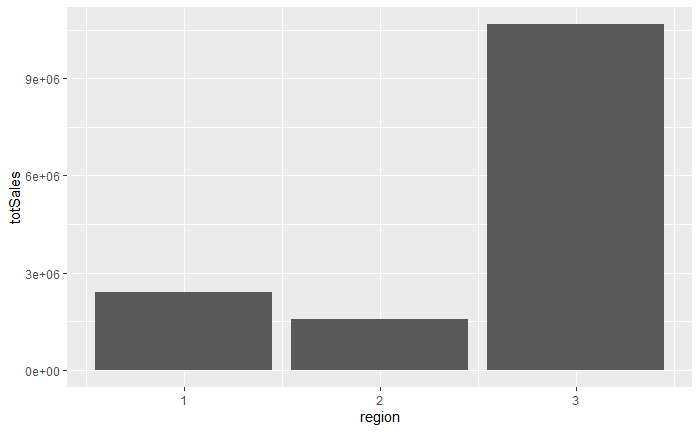

```r
library(ggplot2)
salesChart <- qplot(region, totSales, data=salesRegion, geom="col")
salesChart
```

# Documentation

> *Note: when you install `data.world` you will also receive `dwapi`, a collection of R wrapper functions. Check out the documentation on CRAN to learn more.*
- [`"data.world"` documentation](http://cran.nexr.com/web/packages/data.world/data.world.pdf) (the main data.world R package - useful for configuring API authorizations and for executing SQL or SPARQL queries via R scripts)
- [`"dwapi"` documentation](http://cran.nexr.com/web/packages/dwapi/dwapi.pdf) (a set of wrapper functions for data.world’s REST API endpoints - *installed automatically when you call `install.packages("data.world")`*)

Queries are a powerful feature and are a great tool for pulling and wrangling data. For additional examples, check out data.world tutorials and published queries [here](https://data.world/jonloyens/an-intro-to-dataworld-dataset/query) and [here](https://data.world/jonloyens/intermediate-data-world/query).

##### data.world support docs: https://help.data.world